# Clinical Trial in Soft Tissue Sarcoma

## Response Rate Comparison

### Last Response

**last_response Sheet**: 596 parients in last_response No NAs in RSORRES of last_response

```r
# last_response Sheet
head(last_response)
```

```
## # A tibble: 6 × 5
##   SUBJID RSTEST           RSCAT  RSORRES  RSDY
##    <dbl> <chr>            <chr>  <chr>   <dbl>
## 1 112001 Overall Response RECIST PD        109
## 2 112002 Overall Response RECIST PD        254
## 3 112003 Overall Response RECIST PR        122
## 4 112004 Overall Response RECIST PR        725
## 5 112005 Overall Response RECIST SD        144
## 6 112006 Overall Response RECIST SD        122
```

```r
dim(last_response) # 596 parients in last_response
```

```
## [1] 596   5
```

```r
# RSCAT
# check the total levels of RSCAT of last_response
length(unique(last_response$RSCAT))
```

```
## [1] 1
```

```r
# check if there is NAs in RSCAT of last_response
sum(is.na(last_response$RSCAT))# No Na in RSCAT
```

```
## [1] 0
```

```r
# RSORRES
# check the total levels of RSORRES of last_response
length(unique(last_response$RSORRES))
```

```
## [1] 5
```

```r
length(last_response$RSORRES) #Notice only 596 patients has the RSORRES in last_response
```

```
## [1] 596
```

```r
# check if there are NAs in RSORRES of last_response
sum(is.na(last_response$RSORRES)) # No NAs in RSORRES of last_response
```

```
## [1] 0
```

```r
# Create table1 showing frequency of each levels occurrence in RSORRES of last_response
table1 <- data.frame(table(last_response$RSORRES))
table1
```

```
##   Var1 Freq
## 1   CR    5
## 2   NE    5
## 3   PD  403
## 4   PR   52
## 5   SD  131
```

inner_join Baseline_Information and last_response: ????check the outcome of inner_join 635-596-594

```r
# check the dims of both dataset
dim(new_base)
```

```
## [1] 635  13
```

```r
dim(last_response)
```

```
## [1] 596   5
```

```r
#inner_join
Base_Last <- inner_join(last_response, new_base, by = "SUBJID")
dim(Base_Last)
```

```
## [1] 594  17
```

```r
#create data set inner_last only containing ARMCD,RSORRES
inner_last <- Base_Last %>%
  select(ARMCD,RSORRES)
unique(inner_last$RSORRES)
```

```
## [1] "PD" "PR" "SD" "CR" "NE"
```

```r
sum(is.na(inner_last$RSORRES))
```

```
## [1] 0
```

last_response: Method_2by2

```r
# RSORRES: Response assessment, PD: Progressive disease, PR = Partial, response, CR = Complete response, SD = stable disease, NE = Inevaluable
inner_last%>%
  mutate(result =recode(RSORRES,"PD"="No Response", "PR"="Partial response", "SD" = "No Response", "CR"="Complete response", "NE" ="No Response")) -> inner_last_2by2

sampProps_last <- prop.table(table(inner_last_2by2$ARMCD, inner_last_2by2$result),1)
sampProps_last
```

```
##
##     Complete response No Response Partial response
##   A       0.006688963 0.906354515      0.086956522
##   B       0.010169492 0.901694915      0.088135593
```

```r
table(inner_last_2by2$ARMCD, inner_last_2by2$result)
```

```
##
##     Complete response No Response Partial response
##   A                 2         271               26
##   B                 3         266               26
```

```r
# sample difference
sampDiff_last <- sampProps_last[2,2]-sampProps_last[1,2]
sampDiff_last
```

```
## [1] -0.0046596
```

```r
# Method1: chisq test
chisq.test(table(inner_last_2by2$ARMCD, inner_last_2by2$result), correct =F)
```

```
##
##  Pearson's Chi-squared test
##
## data:  table(inner_last_2by2$ARMCD, inner_last_2by2$result)
## X-squared = 0.21963, df = 2, p-value = 0.896
```

```r
# Method2: relocation sampling
random.allo <-function(reps, group, outcome){
  propDiff <-rep(0,reps)
  for(i in 1:reps){
    randomGroup <-sample(group, replace=FALSE)
    propTable <-prop.table(table(randomGroup,outcome),1)
    propDiff[i] <- propTable[2,2]-propTable[1,2]
  }
  propDiff
}

sampleDiff_last <-random.allo(5000, inner_last_2by2$ARMCD, inner_last_2by2$result)
1-(sum(sampDiff_last< -(abs(sampleDiff_last))|sampDiff_last> abs(sampleDiff_last)))/5000
```

```
## [1] 0.8886
```

### Best Response

**best_response Sheet**: 48 Nas of 640 patients in BESTRESP of best_response only 592 patients could be used (640-48 = 592)

```r
# best_response Sheet
head(best_response)
```

```
## # A tibble: 6 × 2
##   SUBJID BESTRESP
##    <dbl> <chr>
## 1 112001 PD
## 2 112002 SD
## 3 112003 PR
## 4 112004 PR
## 5 112005 SD
## 6 112006 SD
```

```r
dim(best_response) # 640 patients in best_response
```

```
## [1] 640   2
```

```r
# check the total levels of BESTRESP of best_response
length(unique(best_response$BESTRESP))
```

```
## [1] 6
```

```r
length(best_response$BESTRESP) #640 patients have the BESTRESP in best_response
```

```
## [1] 640
```

```r
# check if there are NAs in BESTRESP of last_response
sum(is.na(best_response$BESTRESP))# There are 48 NAs in BESTRESP of best_response
```

```
## [1] 48
```

```r
# Create table1 showing frequency of each levels occurrence in BESTRESPof last_response
table1 <- data.frame(table(best_response$BESTRESP))
table1
```

```
##   Var1 Freq
## 1   CR    8
## 2   NE    2
## 3   PD  145
## 4   PR  141
## 5   SD  296
```

inner_join Baseline_Information and best_response

```r
# check the dims of both dataset
dim(baseline)
```

```
## [1] 640  13
```

```r
dim(best_response)
```

```
## [1] 640   2
```

```r
#inner_join
Base_Best <- inner_join(new_base, best_response, by = "SUBJID")
dim(Base_Best)
```

```
## [1] 635  14
```

```r
#create data set inner_last only containing ARMCD, BESTRESP
inner_best <- Base_Best %>%
  select(ARMCD,BESTRESP)

unique(inner_best$BESTRESP)
```

```
## [1] "PD" "SD" "PR" NA   "CR" "NE"
```

```r
sum(is.na(inner_best$BESTRESP))# 45 NAs in inner_best, need I drop them to calculate the responce rate? I drop here
```

```
## [1] 45
```

```r
#omit the rows with NAs in inner_best to create the dataset inner_best_nonna
inner_best_nonna <- inner_best %>%
na.omit()
dim(inner_best)
```

```
## [1] 635   2
```

```r
dim(inner_best_nonna)
```

```
## [1] 590   2
```

best_response: Method_2by2

```r
# RSORRES: Response assessment, PD: Progressive disease, PR = Partial, response, CR = Complete response, SD = stable disease, NE = Inevaluable
inner_best_nonna%>%
  mutate(result =recode(BESTRESP,"PD"="No Response", "PR"="Partial response", "SD" = "No Response", "CR"="Complete response", "NE" ="Inevaluable")) -> inner_best_nonna_2by2
dim(inner_best_nonna_2by2)
```

```
## [1] 590   3
```

```r
sampProps_best <- prop.table(table(inner_best_nonna_2by2$ARMCD,  inner_best_nonna_2by2$result),1)
sampProps_best
```

```
##
##     Complete response Inevaluable No Response Partial response
##   A       0.016891892 0.003378378 0.692567568      0.287162162
##   B       0.010204082 0.003401361 0.795918367      0.190476190
```

```r
table(inner_best_nonna_2by2$ARMCD,inner_best_nonna_2by2$result)
```

```
##
##     Complete response Inevaluable No Response Partial response
##   A                 5           1         205               85
##   B                 3           1         234               56
```

```r
# sample difference
sampDiff_best <- sampProps_best[2,2]-sampProps_best[1,2]
sampDiff_best
```

```
## [1] 2.298217e-05
```

```r
# Method1: chisq test
chisq.test(table(inner_best_nonna_2by2$ARMCD, inner_best_nonna_2by2$result), correct = F)$p.value
```

```
## [1] 0.0388902
```

```r
# Method2: relocation sampling
random.allo <-function(reps, group, outcome){
  propDiff <-rep(0,reps)
  for(i in 1:reps){
    randomGroup <-sample(group, replace=FALSE)
    propTable <-prop.table(table(randomGroup,outcome),1)
    propDiff[i] <- propTable[2,2]-propTable[1,2]
  }
  propDiff
}

sampleDiff_best <-random.allo(5000, inner_best_nonna_2by2$ARMCD, inner_best_nonna_2by2$result)
1-(sum(sampDiff_best< -(abs(sampleDiff_best))|sampDiff_best> abs(sampleDiff_best)))/5000
```

```
## [1] 1
```

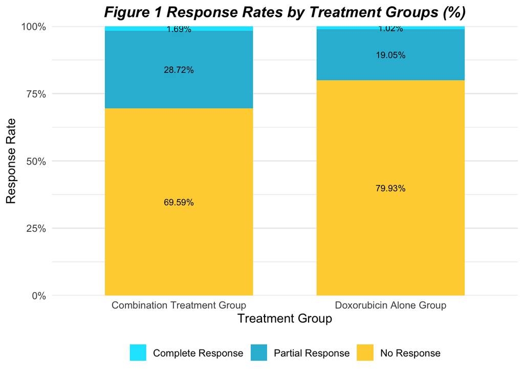

```r
library(dplyr)
library(ggplot2)

# 1) recategorize：CR / PR / No Response
plot_df <- inner_best_nonna_2by2 %>%
  mutate(result3 = case_when(
    grepl("Complete", result, ignore.case = TRUE) ~ "Complete Response",
    grepl("Partial",  result, ignore.case = TRUE) ~ "Partial Response",
    TRUE ~ "No Response"   # SD/PD/NE/NR -> No Response
  )) %>%
  mutate(
    result3 = factor(result3,
                     levels = c("Complete Response","Partial Response","No Response")),
    ARMCD   = factor(ARMCD, labels = c("Combination Treatment Group",
                                       "Doxorubicin Alone Group"))
  ) %>%
  count(ARMCD, result3, name = "n") %>%
  group_by(ARMCD) %>%
  mutate(pct = n / sum(n))

# 2) drawing
ggplot(plot_df, aes(x = ARMCD, y = pct, fill = result3)) +
  geom_col(width = 0.7) +
  geom_text(aes(label = scales::percent(pct, accuracy = 0.01)),
            position = position_stack(vjust = 0.5), size = 3) +
  scale_y_continuous(labels = scales::percent,
                     limits = c(0,1), expand = c(0,0)) +
  scale_fill_manual(values = c("#00E6FF", "#2BBBD8", "#FFD23F"), name = NULL) +
  labs(x = "Treatment Group", y = "Response Rate",
       title = "Figure 1 Response Rates by Treatment Groups (%)") +
  theme_minimal(base_size = 12) +
  theme(legend.position = "bottom",
        plot.title = element_text(hjust = 0.5, face = "bold.italic"))
```

## Summarise Adverse Event Data

```r
# Merge adverse_event and baseline.info dataset. (Select the variables in the dictionary first)
adverse_event <- adverse_event %>%
  inner_join(baseline) %>%
  filter(BECOG %in% c(0,1)) %>%
  arrange(SUBJID) %>%
  select(SUBJID, AESOC, AESER, AEOUT, AETOXGR, STAGE, ARMCD)
aesoc <- adverse_event %>%
  group_by(AESOC) %>%
  summarise(n = n()) %>%
  arrange(desc(n))
# The number of the unique AESOCs.
nrow(aesoc)
```

```
## [1] 24
```

```r
# The proportion of top 10 AESOCs.
prop_top10_aesoc <- sum(aesoc[1:10,2]/nrow(adverse_event))
round(prop_top10_aesoc, 4)
```

```
## [1] 0.9035
```

```r
# The names of top 10 AESOCs.
top10_aesoc <- aesoc[1:10,1]
top10_aesoc
```

```
## # A tibble: 10 × 1
##    AESOC
##    <chr>
##  1 Gastrointestinal disorders
##  2 Blood and lymphatic system disorders
##  3 General disorders and administration site conditions
##  4 Skin and subcutaneous tissue disorders
##  5 Investigations
##  6 Metabolism and nutrition disorders
##  7 Respiratory, thoracic and mediastinal disorders
##  8 Infections and infestations
##  9 Nervous system disorders
## 10 Musculoskeletal and connective tissue disorders
```

- The top 10 among 24 different system organ classes constitute more than 90% of the whole adverse event record size. So it is proper to filter those 10 in the following analysis.

```r
ae_file <- adverse_event %>%
  select(ARMCD, AESOC, AESER, AEOUT, AETOXGR) %>%
  # AETOXGR is originally a numeric and is supposed to be a factor.
  mutate(AETOXGR = as.factor(AETOXGR)) %>%
  # Select the top 10 AESOC and order the result.
  filter(AESOC %in% unlist(top10_aesoc)) %>%
  mutate(AESOC = factor(AESOC, levels = unlist(top10_aesoc)))
ae_file
```

```
## # A tibble: 8,529 × 5
##    ARMCD AESOC                                               AESER AEOUT AETOXGR
##    <chr> <fct>                                               <chr> <chr> <fct>
##  1 B     Gastrointestinal disorders                          N     RECO… 2
##  2 B     Gastrointestinal disorders                          N     RECO… 2
##  3 B     Gastrointestinal disorders                          N     RECO… 2
##  4 B     Gastrointestinal disorders                          Y     RECO… 3
##  5 B     Blood and lymphatic system disorders                N     RECO… 4
##  6 B     Infections and infestations                         Y     RECO… 3
##  7 B     Gastrointestinal disorders                          N     RECO… 3
##  8 A     Nervous system disorders                            N     RECO… 1
##  9 A     Gastrointestinal disorders                          N     NOT … 1
## 10 A     General disorders and administration site conditio… N     RECO… 1
## # ℹ 8,519 more rows
```

## Table. AE Profile Comparison between Arm A and B.

```r
# All the four characteristics are categorial variables. Test is chisq by default.
summary(tableby(ARMCD ~ AESER + AEOUT + AETOXGR + AESOC, data = ae_file))
```

|  | A (N=5400) | B (N=3129) | Total (N=8529) | p value |
| --- | --- | --- | --- | --- |
| **AESER** |  |  |  | 0.235 |
| N | 5130 (95.0%) | 2954 (94.4%) | 8084 (94.8%) |  |
| Y | 270 (5.0%) | 175 (5.6%) | 445 (5.2%) |  |
| **AEOUT** |  |  |  | < 0.001 |
| FATAL | 6 (0.1%) | 2 (0.1%) | 8 (0.1%) |  |
| NOT RECOVERED/NOT RESOLVED | 1221 (22.6%) | 853 (27.3%) | 2074 (24.3%) |  |
| RECOVERED/RESOLVED | 3924 (72.7%) | 2158 (69.0%) | 6082 (71.3%) |  |
| RECOVERED/RESOLVED WITH SEQUELAE | 22 (0.4%) | 12 (0.4%) | 34 (0.4%) |  |
| RECOVERING/RESOLVING | 222 (4.1%) | 100 (3.2%) | 322 (3.8%) |  |
| UNKNOWN | 5 (0.1%) | 4 (0.1%) | 9 (0.1%) |  |
| **AETOXGR** |  |  |  | < 0.001 |
| 1 | 2996 (55.5%) | 1639 (52.4%) | 4635 (54.3%) |  |
| 2 | 1484 (27.5%) | 830 (26.5%) | 2314 (27.1%) |  |
| 3 | 710 (13.1%) | 439 (14.0%) | 1149 (13.5%) |  |
| 4 | 204 (3.8%) | 219 (7.0%) | 423 (5.0%) |  |
| 5 | 6 (0.1%) | 2 (0.1%) | 8 (0.1%) |  |
| **AESOC** |  |  |  | < 0.001 |
| Gastrointestinal disorders | 1404 (26.0%) | 896 (28.6%) | 2300 (27.0%) |  |
| Blood and lymphatic system disorders | 727 (13.5%) | 428 (13.7%) | 1155 (13.5%) |  |
| General disorders and administration site conditions | 600 (11.1%) | 413 (13.2%) | 1013 (11.9%) |  |
| Skin and subcutaneous tissue disorders | 697 (12.9%) | 236 (7.5%) | 933 (10.9%) |  |
| Investigations | 418 (7.7%) | 316 (10.1%) | 734 (8.6%) |  |
| Metabolism and nutrition disorders | 324 (6.0%) | 206 (6.6%) | 530 (6.2%) |  |
| Respiratory, thoracic and mediastinal disorders | 333 (6.2%) | 194 (6.2%) | 527 (6.2%) |  |
| Infections and infestations | 347 (6.4%) | 128 (4.1%) | 475 (5.6%) |  |
| Nervous system disorders | 286 (5.3%) | 164 (5.2%) | 450 (5.3%) |  |
| Musculoskeletal and connective tissue disorders | 264 (4.9%) | 148 (4.7%) | 412 (4.8%) |  |